# Project: Investigate a Dataset (TMDB Movie Dataset)

- Introduction
- Data Wrangling
- Exploratory Data Analysis
- Conclusions

## Introduction

> The TMDB Movie Dataset, available on Kaggle, is selected for data investigation and analysis. The dataset is downloaded in 'csv' format and contains data of around 10,000 movies. The information available includes the budget, revenue, cast, director, genre, runtime, production company, release date and viewer voting data. In addition, revenue and budget are adjusted to inflation and are available in separate columns named revenue_adj and budget_adj respectively.

> **Note:** For the analysis, machine learning or inferential statistics methods are not used. Therefore, all findings presented in this report are tentative.

> The following research questions will be explored in the report. The research questions are split into 2 main categories which consists of multiple sub-questions.

> **Research Question 1: Trend Analysis**
> - 1a. What is the general trend of the number of movies released over the years?
> - 1b. What is the general trend of the average profit (adj) over the years?
> - 1c. What is the general trend of the mean popularity of movies over the years?

> **Research Question 2: Profitability Analysis**
> - 2a. What is the correlation between popularity and profitability?
> - 2b. What is the correlation between budget and profitability?
> - 2c. What is the correlation between budget, revenue and profit over the years?
> - 2d. Which are the top 5 genres in movies?

```python
# Importing the necessary packages for the analysis and visualization
import pandas as pd
import numpy as np
import matplotlib.pyplot as plt
import seaborn as sns
%matplotlib inline


# Setting the style of the graphs
sns.set_style('darkgrid')
```

## Data Wrangling

> In this section, we will load the TMDB movie dataset csv file, display the basic information of the dataset, check for data cleanliness, and then trim and clean the dataset for analysis.

> The main goal of this section is to load the data, understand the basic properties of the dataset and decide which columns will need cleaning or elimination.

### General Properties

```python
# Load your data and print out a few lines. Perform operations to inspect data
#   types and look for instances of missing or possibly errant data.

#Reading the csv file using pandas read_csv and displaying the first 5 rows of the dataset
df = pd.read_csv('tmdb-movies.csv')
df.head()
```

|  | id | imdb_id | popularity | budget | revenue | original_title | cast | homepage | director | tagline | ... | overview | runtime | genres | production_companies | release_date | vote_count | vote_average | release_year | budget_adj | revenue_adj |
| --- | --- | --- | --- | --- | --- | --- | --- | --- | --- | --- | --- | --- | --- | --- | --- | --- | --- | --- | --- | --- | --- |
| 0 | 135397 | tt0369610 | 32.985763 | 150000000 | 1513528810 | Jurassic World | Chris Pratt\|Bryce Dallas Howard\|Irrfan Khan\|Vi... | http://www.jurassicworld.com/ | Colin Trevorrow | The park is open. | ... | Twenty-two years after the events of Jurassic ... | 124 | Action\|Adventure\|Science Fiction\|Thriller | Universal Studios\|Amblin Entertainment\|Legenda... | 6/9/15 | 5562 | 6.5 | 2015 | 1.379999e+08 | 1.392446e+09 |
| 1 | 76341 | tt1392190 | 28.419936 | 150000000 | 378436354 | Mad Max: Fury Road | Tom Hardy\|Charlize Theron\|Hugh Keays-Byrne\|Nic... | http://www.madmaxmovie.com/ | George Miller | What a Lovely Day. | ... | An apocalyptic story set in the furthest reach... | 120 | Action\|Adventure\|Science Fiction\|Thriller | Village Roadshow Pictures\|Kennedy Miller Produ... | 5/13/15 | 6185 | 7.1 | 2015 | 1.379999e+08 | 3.481613e+08 |
| 2 | 262500 | tt2908446 | 13.112507 | 110000000 | 295238201 | Insurgent | Shailene Woodley\|Theo James\|Kate Winslet\|Ansel... | http://www.thedivergentseries.movie/#insurgent | Robert Schwentke | One Choice Can Destroy You | ... | Beatrice Prior must confront her inner demons ... | 119 | Adventure\|Science Fiction\|Thriller | Summit Entertainment\|Mandeville Films\|Red Wago... | 3/18/15 | 2480 | 6.3 | 2015 | 1.012000e+08 | 2.716190e+08 |
| 3 | 140607 | tt2488496 | 11.173104 | 200000000 | 2068178225 | Star Wars: The Force Awakens | Harrison Ford\|Mark Hamill\|Carrie Fisher\|Adam D... | http://www.starwars.com/films/star-wars-episod... | J.J. Abrams | Every generation has a story. | ... | Thirty years after defeating the Galactic Empi... | 136 | Action\|Adventure\|Science Fiction\|Fantasy | Lucasfilm\|Truenorth Productions\|Bad Robot | 12/15/15 | 5292 | 7.5 | 2015 | 1.839999e+08 | 1.902723e+09 |
| 4 | 168259 | tt2820852 | 9.335014 | 190000000 | 1506249360 | Furious 7 | Vin Diesel\|Paul Walker\|Jason Statham\|Michelle ... | http://www.furious7.com/ | James Wan | Vengeance Hits Home | ... | Deckard Shaw seeks revenge against Dominic Tor... | 137 | Action\|Crime\|Thriller | Universal Pictures\|Original Film\|Media Rights ... | 4/1/15 | 2947 | 7.3 | 2015 | 1.747999e+08 | 1.385749e+09 |

5 rows × 21 columns

```python
# Check the no. of rows and columns in the data frame
print("The number of rows and columns in the original dataset is: {}".format(df.shape))
```

```
The number of rows and columns in the original dataset is: (10866, 21)
```

```python
# Check the data types of columns and no. of missing data for each column
df.info()
```

```
<class 'pandas.core.frame.DataFrame'>
RangeIndex: 10866 entries, 0 to 10865
Data columns (total 21 columns):
 #   Column                Non-Null Count  Dtype
---  ------                --------------  -----
 0   id                    10866 non-null  int64
 1   imdb_id               10856 non-null  object
 2   popularity            10866 non-null  float64
 3   budget                10866 non-null  int64
 4   revenue               10866 non-null  int64
 5   original_title        10866 non-null  object
 6   cast                  10790 non-null  object
 7   homepage              2936 non-null   object
 8   director              10822 non-null  object
 9   tagline               8042 non-null   object
 10  keywords              9373 non-null   object
 11  overview              10862 non-null  object
 12  runtime               10866 non-null  int64
 13  genres                10843 non-null  object
 14  production_companies  9836 non-null   object
 15  release_date          10866 non-null  object
 16  vote_count            10866 non-null  int64
 17  vote_average          10866 non-null  float64
 18  release_year          10866 non-null  int64
 19  budget_adj            10866 non-null  float64
 20  revenue_adj           10866 non-null  float64
dtypes: float64(4), int64(6), object(11)
memory usage: 1.7+ MB
```

Columns having less than 10866 rows are missing data. From the above overview, imdb_id, cast, homepage, director, tagline, keywords, overview, genres, production_companies are missing data.

```python
# Check the statistical property of the dataset
df.describe()
```

|  | id | popularity | budget | revenue | runtime | vote_count | vote_average | release_year | budget_adj | revenue_adj |
| --- | --- | --- | --- | --- | --- | --- | --- | --- | --- | --- |
| count | 10866.000000 | 10866.000000 | 1.086600e+04 | 1.086600e+04 | 10866.000000 | 10866.000000 | 10866.000000 | 10866.000000 | 1.086600e+04 | 1.086600e+04 |
| mean | 66064.177434 | 0.646441 | 1.462570e+07 | 3.982332e+07 | 102.070863 | 217.389748 | 5.974922 | 2001.322658 | 1.755104e+07 | 5.136436e+07 |
| std | 92130.136561 | 1.000185 | 3.091321e+07 | 1.170035e+08 | 31.381405 | 575.619058 | 0.935142 | 12.812941 | 3.430616e+07 | 1.446325e+08 |
| min | 5.000000 | 0.000065 | 0.000000e+00 | 0.000000e+00 | 0.000000 | 10.000000 | 1.500000 | 1960.000000 | 0.000000e+00 | 0.000000e+00 |
| 25% | 10596.250000 | 0.207583 | 0.000000e+00 | 0.000000e+00 | 90.000000 | 17.000000 | 5.400000 | 1995.000000 | 0.000000e+00 | 0.000000e+00 |
| 50% | 20669.000000 | 0.383856 | 0.000000e+00 | 0.000000e+00 | 99.000000 | 38.000000 | 6.000000 | 2006.000000 | 0.000000e+00 | 0.000000e+00 |
| 75% | 75610.000000 | 0.713817 | 1.500000e+07 | 2.400000e+07 | 111.000000 | 145.750000 | 6.600000 | 2011.000000 | 2.085325e+07 | 3.369710e+07 |
| max | 417859.000000 | 32.985763 | 4.250000e+08 | 2.781506e+09 | 900.000000 | 9767.000000 | 9.200000 | 2015.000000 | 4.250000e+08 | 2.827124e+09 |

```python
# Check if column 'director' has rows with multiple values separated by '|'
# This step is necessary since the first 5 rows do not have multiple values in the 'director' column
director_pipe = df.director.str.contains('|').sum()
print("There are {} rows in the 'director' column that contain multiple values separated by a '|' character".format(director_pipe))
```

```
There are 10822 rows in the 'director' column that contain multiple values separated by a '|' character
```

### Observations and Data Cleaning Steps

#### Observations on the dataset

> 1. Since the 'release year' varies from 1960 till 2015 (based on min and max values), we use the 'budget_adj' and 'revenue_adj' in the analysis to have a fair comparison that takes inflation into account.
> 2. Some columns contain huge number of missing values. Missing values are replaced with their mean values.
> 3. Column 'homepage' has a lot of missing data. Also, for the analysis question we have posed, columns 'id', 'imdb_id', 'homepage', 'tagline' are not relevant. Hence, we can eliminate these columns. 'keyword' to be retained for now.
> 4. Scientific notation (numbers with 'e') is used in 'budget_adj' and 'revenue_adj' columns. This requires conversion to integer format for our analysis.
> 5. Column 'cast' contains some odd characters. As mentioned in the dataset instruction overview and notes, the odd characters are left unmodified.

#### Data Cleaning Steps

##### 2. Delete rows with duplicate values

##### 3. Handling missing values

##### 4. Formatting changes

> Columns: 'cast', 'director', 'genres' and 'production companies' contain multiple values separated by a pipe character '|'. We change the format of these later in our analysis when they are specifically analysed.

##### a. Change format of 'release date' to datetime

##### b. Change format of 'budget_adj' and 'revenue_adj' from float to int

> > This step is required to convert the scientific notation (numbers with 'e') to an 'int' format for easy analysis.

##### 5. Create 'profit' and 'profit_adj' columns

### Data Cleaning

**Step 1:** Drop the columns that are not useful for our analysis.

```python
# Drop columns that are not required for our analysis
df.drop(['id','imdb_id','homepage','tagline','overview'], axis=1, inplace=True)
```

```python
# Check the dataframe to confirm if the selected columns are dropped
df.head()
```

|  | popularity | budget | revenue | original_title | cast | director | keywords | runtime | genres | production_companies | release_date | vote_count | vote_average | release_year | budget_adj | revenue_adj |
| --- | --- | --- | --- | --- | --- | --- | --- | --- | --- | --- | --- | --- | --- | --- | --- | --- |
| 0 | 32.985763 | 150000000 | 1513528810 | Jurassic World | Chris Pratt\|Bryce Dallas Howard\|Irrfan Khan\|Vi... | Colin Trevorrow | monster\|dna\|tyrannosaurus rex\|velociraptor\|island | 124 | Action\|Adventure\|Science Fiction\|Thriller | Universal Studios\|Amblin Entertainment\|Legenda... | 6/9/15 | 5562 | 6.5 | 2015 | 1.379999e+08 | 1.392446e+09 |
| 1 | 28.419936 | 150000000 | 378436354 | Mad Max: Fury Road | Tom Hardy\|Charlize Theron\|Hugh Keays-Byrne\|Nic... | George Miller | future\|chase\|post-apocalyptic\|dystopia\|australia | 120 | Action\|Adventure\|Science Fiction\|Thriller | Village Roadshow Pictures\|Kennedy Miller Produ... | 5/13/15 | 6185 | 7.1 | 2015 | 1.379999e+08 | 3.481613e+08 |
| 2 | 13.112507 | 110000000 | 295238201 | Insurgent | Shailene Woodley\|Theo James\|Kate Winslet\|Ansel... | Robert Schwentke | based on novel\|revolution\|dystopia\|sequel\|dyst... | 119 | Adventure\|Science Fiction\|Thriller | Summit Entertainment\|Mandeville Films\|Red Wago... | 3/18/15 | 2480 | 6.3 | 2015 | 1.012000e+08 | 2.716190e+08 |
| 3 | 11.173104 | 200000000 | 2068178225 | Star Wars: The Force Awakens | Harrison Ford\|Mark Hamill\|Carrie Fisher\|Adam D... | J.J. Abrams | android\|spaceship\|jedi\|space opera\|3d | 136 | Action\|Adventure\|Science Fiction\|Fantasy | Lucasfilm\|Truenorth Productions\|Bad Robot | 12/15/15 | 5292 | 7.5 | 2015 | 1.839999e+08 | 1.902723e+09 |
| 4 | 9.335014 | 190000000 | 1506249360 | Furious 7 | Vin Diesel\|Paul Walker\|Jason Statham\|Michelle ... | James Wan | car race\|speed\|revenge\|suspense\|car | 137 | Action\|Crime\|Thriller | Universal Pictures\|Original Film\|Media Rights ... | 4/1/15 | 2947 | 7.3 | 2015 | 1.747999e+08 | 1.385749e+09 |

**Step 2:** Drop the duplicate rows.

```python
# Check for duplicate rows
dup_rows = df.duplicated().sum()
print("There are {} duplicate row(s) in the dataset which need to be dropped.".format(dup_rows))
```

```
There are 1 duplicate row(s) in the dataset which need to be dropped.
```

```python
# Drop the duplicate rows and then check if duplicates are removed
df.drop_duplicates(inplace=True)
dup_rows = df.duplicated().sum()
print("There are {} duplicate row(s) in the dataset which need to be dropped.".format(dup_rows))
```

```
There are 0 duplicate row(s) in the dataset which need to be dropped.
```

**Step 3:** Handling missing values.

Next, let's check the number of 0 values (missing values) in each column. This is important to consider since 0 values in budget and revenue, if any, can impact the quality of our analysis. There are two ways to handle missing values:

1. Drop those rows.
2. Replace missing values with mean values.

```python
# Check the count of zero (0) values
df.isin([0]).sum()
```

```
popularity                 0
budget                  5696
revenue                 6016
original_title             0
cast                       0
director                   0
keywords                   0
runtime                   31
genres                     0
production_companies       0
release_date               0
vote_count                 0
vote_average               0
release_year               0
budget_adj              5696
revenue_adj             6016
dtype: int64
```

Budget and Revenue columns have a huge number of 0 values. It is obvoius that the budget and revenue cannot be zero. They are missing values registered as zeros. This needs to be handled.

Each of the already mentioned ways (drop vs replacing with mean) have their pros and cons. For our analysis, since we see a lot of 0 values in budget_adj and revenue_adj, the missing values are replaced them with the respective mean values.

For our analysis, we replace the missing values with their respective mean values.

**Note:** Comparing the result of entirely dropping the missing value rows with the result of rows filled with mean values is beyond the scope of our analysis.

```python
# Check count of columns with NaN values
df.isna().sum()
```

```
popularity                 0
budget                     0
revenue                    0
original_title             0
cast                      76
director                  44
keywords                1493
runtime                    0
genres                    23
production_companies    1030
release_date               0
vote_count                 0
vote_average               0
release_year               0
budget_adj                 0
revenue_adj                0
dtype: int64
```

```python
# Replace 0 values in budget, revenue, budget_adj and revenue_adj with their respective mean values

df['budget'] = df['budget'].replace(0,df['budget'].mean())
df['revenue'] = df['revenue'].replace(0,df['revenue'].mean())
df['budget_adj'] = df['budget_adj'].replace(0,df['budget_adj'].mean())
df['revenue_adj'] = df['revenue_adj'].replace(0,df['revenue_adj'].mean())
```

```python
# Check the data set to confirm that 0s are replaced with mean in the columns mentioned in the previous step
df.isin([0]).sum()
```

```
popularity               0
budget                   0
revenue                  0
original_title           0
cast                     0
director                 0
keywords                 0
runtime                 31
genres                   0
production_companies     0
release_date             0
vote_count               0
vote_average             0
release_year             0
budget_adj               0
revenue_adj              0
dtype: int64
```

After replacing the 0s with their mean values, only "runtime" is found to have 0 values. These 0 values will be replaced with NaN and these rows will be dropped together with other NaN rows of other columns.

```python
# Replace 0 values with NaN
df['runtime'] = df['runtime'].replace(0,np.NAN)

# Check and confirm the changes
df.isna().sum()
```

```
popularity                 0
budget                     0
revenue                    0
original_title             0
cast                      76
director                  44
keywords                1493
runtime                   31
genres                    23
production_companies    1030
release_date               0
vote_count                 0
vote_average               0
release_year               0
budget_adj                 0
revenue_adj                0
dtype: int64
```

The NaN values adversely impact the accuracy of our analysis. Hence, these NaN value rows will be dropped in the next step.

**Note** : Since cast, director, keywords and production companies are discrete variables which cannot have a mean value, they cannot be replaced with mean values like we did for the measured variables such as budget and revenue.

```python
# Drop rows with NaN values
df.dropna(inplace=True)
```

```python
# Check the dataset to confirm NaN values are dropped
df.isna().sum()
```

```
popularity              0
budget                  0
revenue                 0
original_title          0
cast                    0
director                0
keywords                0
runtime                 0
genres                  0
production_companies    0
release_date            0
vote_count              0
vote_average            0
release_year            0
budget_adj              0
revenue_adj             0
dtype: int64
```

There are no columns in the dataset with NaN values.

```python
# Recheck the no. of rows and columns in the modified dataset
print("The number of rows and columns in the modified dataset is: {}".format(df.shape))
```

```
The number of rows and columns in the modified dataset is: (8659, 16)
```

**Step 4:** Formatting Changes.

```python
# Change the format of "release date" from string to datetime
df['release_date'] = pd.to_datetime(df['release_date'], errors = 'ignore')
```

We now create a function to convert float to int. This is then used to convert 'budget_adj' and 'revenue_adj' from float to int.

**Note** : Replacing 0s with mean values in 'budget' and 'revenue' changes the data type to float. So we include these two columns as well when converting from float to int.

```python
# Create a function to convert float to int
def float_to_int(number):
    return int(number)

# Use this function to convert budget_adj and revenue_adj
df['budget_adj'] = df['budget_adj'].apply(float_to_int)
df['revenue_adj'] = df['revenue_adj'].apply(float_to_int)
df['budget'] = df['budget'].apply(float_to_int)
df['revenue'] = df['revenue'].apply(float_to_int)
```

Note: "np.int" was initially used in the above function. A deprecation error was displayed and hence it was replaced with "int".

```python
# Confirm the format change of 'budget_adj' and 'revenue_adj' from float to int
df.info()
```

```
<class 'pandas.core.frame.DataFrame'>
Int64Index: 8659 entries, 0 to 10865
Data columns (total 16 columns):
 #   Column                Non-Null Count  Dtype
---  ------                --------------  -----
 0   popularity            8659 non-null   float64
 1   budget                8659 non-null   int64
 2   revenue               8659 non-null   int64
 3   original_title        8659 non-null   object
 4   cast                  8659 non-null   object
 5   director              8659 non-null   object
 6   keywords              8659 non-null   object
 7   runtime               8659 non-null   float64
 8   genres                8659 non-null   object
 9   production_companies  8659 non-null   object
 10  release_date          8659 non-null   datetime64[ns]
 11  vote_count            8659 non-null   int64
 12  vote_average          8659 non-null   float64
 13  release_year          8659 non-null   int64
 14  budget_adj            8659 non-null   int64
 15  revenue_adj           8659 non-null   int64
dtypes: datetime64[ns](1), float64(3), int64(6), object(6)
memory usage: 1.1+ MB
```

**Step 4:** Create 'profit' and 'profit_adj'

```python
# Create 'profit' and 'profit_adj' columns
df['profit'] = df['revenue'] - df['budget']
df['profit_adj'] = df ['revenue_adj'] - df['budget_adj']
df.head()
```

|  | popularity | budget | revenue | original_title | cast | director | keywords | runtime | genres | production_companies | release_date | vote_count | vote_average | release_year | budget_adj | revenue_adj | profit | profit_adj |
| --- | --- | --- | --- | --- | --- | --- | --- | --- | --- | --- | --- | --- | --- | --- | --- | --- | --- | --- |
| 0 | 32.985763 | 150000000 | 1513528810 | Jurassic World | Chris Pratt\|Bryce Dallas Howard\|Irrfan Khan\|Vi... | Colin Trevorrow | monster\|dna\|tyrannosaurus rex\|velociraptor\|island | 124.0 | Action\|Adventure\|Science Fiction\|Thriller | Universal Studios\|Amblin Entertainment\|Legenda... | 2015-06-09 | 5562 | 6.5 | 2015 | 137999939 | 1392445892 | 1363528810 | 1254445953 |
| 1 | 28.419936 | 150000000 | 378436354 | Mad Max: Fury Road | Tom Hardy\|Charlize Theron\|Hugh Keays-Byrne\|Nic... | George Miller | future\|chase\|post-apocalyptic\|dystopia\|australia | 120.0 | Action\|Adventure\|Science Fiction\|Thriller | Village Roadshow Pictures\|Kennedy Miller Produ... | 2015-05-13 | 6185 | 7.1 | 2015 | 137999939 | 348161292 | 228436354 | 210161353 |
| 2 | 13.112507 | 110000000 | 295238201 | Insurgent | Shailene Woodley\|Theo James\|Kate Winslet\|Ansel... | Robert Schwentke | based on novel\|revolution\|dystopia\|sequel\|dyst... | 119.0 | Adventure\|Science Fiction\|Thriller | Summit Entertainment\|Mandeville Films\|Red Wago... | 2015-03-18 | 2480 | 6.3 | 2015 | 101199955 | 271619025 | 185238201 | 170419070 |
| 3 | 11.173104 | 200000000 | 2068178225 | Star Wars: The Force Awakens | Harrison Ford\|Mark Hamill\|Carrie Fisher\|Adam D... | J.J. Abrams | android\|spaceship\|jedi\|space opera\|3d | 136.0 | Action\|Adventure\|Science Fiction\|Fantasy | Lucasfilm\|Truenorth Productions\|Bad Robot | 2015-12-15 | 5292 | 7.5 | 2015 | 183999919 | 1902723129 | 1868178225 | 1718723210 |
| 4 | 9.335014 | 190000000 | 1506249360 | Furious 7 | Vin Diesel\|Paul Walker\|Jason Statham\|Michelle ... | James Wan | car race\|speed\|revenge\|suspense\|car | 137.0 | Action\|Crime\|Thriller | Universal Pictures\|Original Film\|Media Rights ... | 2015-04-01 | 2947 | 7.3 | 2015 | 174799923 | 1385748801 | 1316249360 | 1210948878 |

Let's create a histogram to qucikly check the distribution of variables in the dataset.

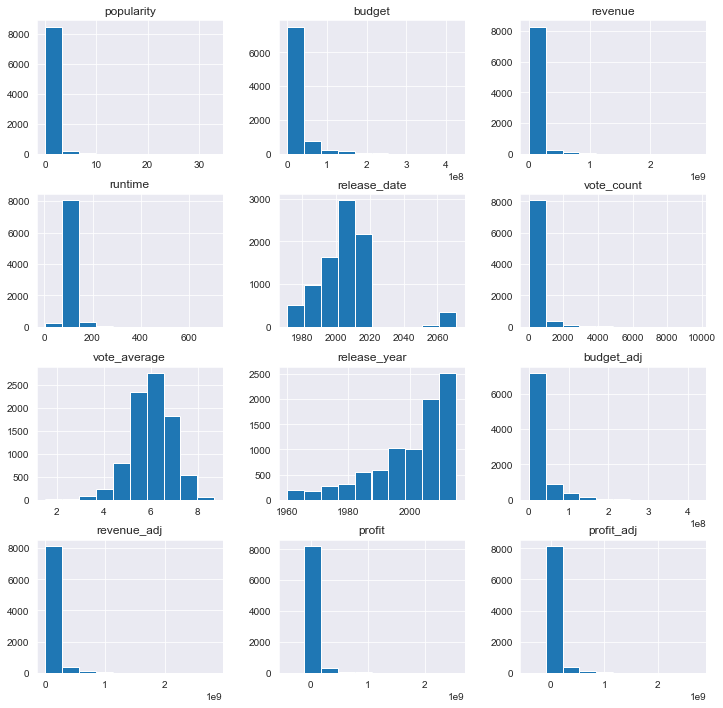

```python
# A quick check of the dataset variables using histograms
df.hist(figsize=(12,12));
```

Some quick insights on the dataset can be obtained from the histogram above.

Note that the histogram for 'release_date' shows weird values such as >2060. We do not clean the data further unless it affects our analysis. In the next section, we explore the data by posing research questions and analysing the data to answer them.

## Exploratory Data Analysis

### Research Question 1: Trend Analysis

> **Q 1a. What is the general trend of the number of movies released over the years?**

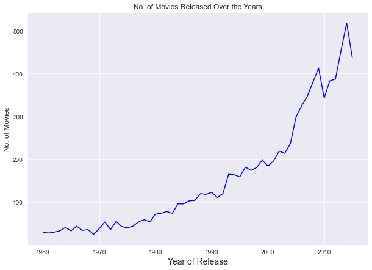

```python
# Count the number of movies per release year and create a new data frame for plotting the trend
df_movie_count = df.groupby('release_year', as_index=False)['original_title'].count()
plt.figure(figsize=(10,7))
plt.plot(df_movie_count['release_year'],df_movie_count['original_title'], color='blue');

# Assign graph title and axes labels
plt.title('No. of Movies Released Over the Years')
plt.xlabel('Year of Release', fontsize=14)
plt.ylabel('No. of Movies', fontsize=12)
```

> > **Q 1a. Quick observation:**
> > - The number of movies released has steadily increased over the years.
> > - Since the year 2000, there has been a sharp increase in the number of movies.

> **Q 1b. What is the general trend of the average profit (adj) over the years?**

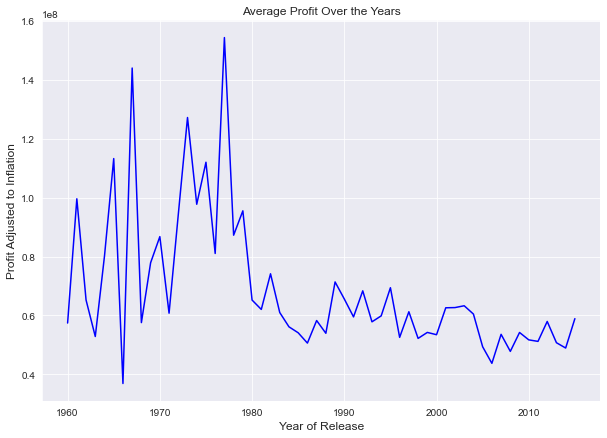

```python
# Calculate the mean profit_adj per release year and plot a line graph

df_mean_profit = df.groupby('release_year', as_index=False)['profit_adj'].mean()
plt.figure(figsize=(10,7))
plt.plot(df_mean_profit['release_year'],df_mean_profit['profit_adj'], color='blue');

# Assign graph title and axes labels
plt.title('Average Profit Over the Years')
plt.xlabel('Year of Release', fontsize=12)
plt.ylabel('Profit Adjusted to Inflation', fontsize=12)
```

```python
# Check for min and max profit years

# Year with min avergae profit
print(df_mean_profit[df_mean_profit.profit_adj == df_mean_profit.profit_adj.min()])

# Year with max avergae profit
print(df_mean_profit[df_mean_profit.profit_adj == df_mean_profit.profit_adj.max()])
```

```
   release_year    profit_adj
6          1966  3.691824e+07
    release_year    profit_adj
17          1977  1.542806e+08
```

> **Q 1c. What is the general trend of the mean popularity of movies over the years?**

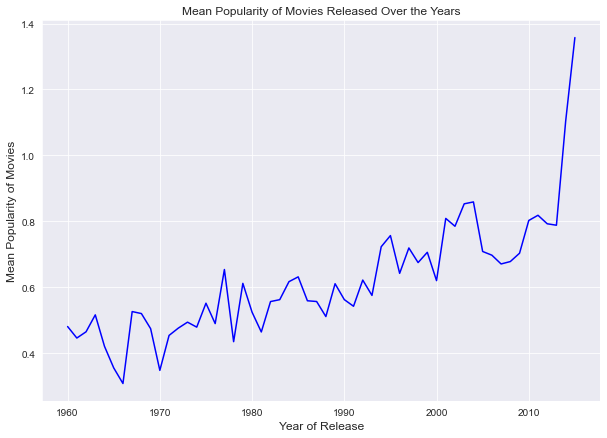

```python
# Mean popularity of movies released
df_movie_count = df.groupby('release_year', as_index=False)['popularity'].mean()
plt.figure(figsize=(10,7))
plt.plot(df_movie_count['release_year'],df_movie_count['popularity'], color='blue');

# Assign graph title and axes labels
plt.title('Mean Popularity of Movies Released Over the Years')
plt.xlabel('Year of Release', fontsize=12)
plt.ylabel('Mean Popularity of Movies', fontsize=12)
```

Before delving deeper into our analysis, let us get a feel of how the different variables interact with each other in the dataset.

**Note:** The scatter matrix overview is only to get an idea of how the variables in the dataset interact with each other. Detialed analysis with specific variables will follow further.

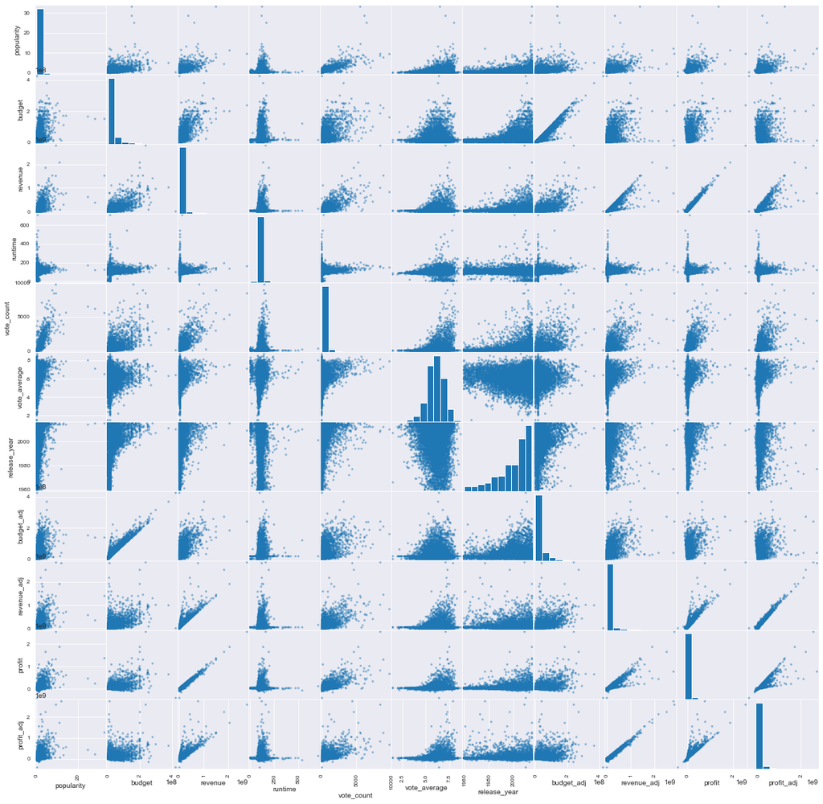

```python
# Create a quick Scatter plot to get an overview of the relationships between various variables.
pd.plotting.scatter_matrix(df, figsize=(20,20));
```

A quick look at the above scatter matrix shows us that specific variables have a clear correlation while with others, it is difficult to identify at the first glance.

### Research Question 2: Profitabiliy Analysis

> **Q 2a. What is the correlation between popularity and profitability?**

To analyse the impact of different variables on the profitability of movies, let us first create a subset of highly profitable movies. In the next step, we shall narrow down the analysis to the last 10 years in the data set.

```python
# Format scientific notation into readable digits
pd.set_option('display.float_format', lambda x: '%.2f' % x)

# Check the basic statistics of the dataset again
df.describe()
```

|  | popularity | budget | revenue | runtime | vote_count | vote_average | release_year | budget_adj | revenue_adj | profit | profit_adj |
| --- | --- | --- | --- | --- | --- | --- | --- | --- | --- | --- | --- |
| count | 8659.00 | 8659.00 | 8659.00 | 8659.00 | 8659.00 | 8659.00 | 8659.00 | 8659.00 | 8659.00 | 8659.00 | 8659.00 |
| mean | 0.74 | 24367494.10 | 68252102.82 | 103.90 | 264.40 | 6.00 | 2000.12 | 29297725.36 | 88135289.58 | 43884608.72 | 58837564.22 |
| std | 1.09 | 30746449.77 | 123152088.75 | 26.05 | 635.42 | 0.89 | 13.22 | 33371276.28 | 151435333.48 | 103818904.06 | 134189167.04 |
| min | 0.00 | 1.00 | 2.00 | 3.00 | 10.00 | 1.50 | 1960.00 | 0.00 | 2.00 | -413912431.00 | -413912431.00 |
| 25% | 0.25 | 14624286.00 | 32003893.00 | 91.00 | 21.00 | 5.50 | 1993.00 | 17549894.00 | 44325832.50 | 8910410.50 | 12638271.50 |
| 50% | 0.45 | 14624286.00 | 39826896.00 | 100.00 | 54.00 | 6.10 | 2004.00 | 17549894.00 | 51369001.00 | 25202610.00 | 33819107.00 |
| 75% | 0.84 | 21000000.00 | 39826896.00 | 113.00 | 200.00 | 6.60 | 2011.00 | 28133578.50 | 55377115.00 | 33520757.00 | 45012948.50 |
| max | 32.99 | 425000000.00 | 2781505847.00 | 705.00 | 9767.00 | 8.70 | 2015.00 | 425000000.00 | 2827123750.00 | 2544505847.00 | 2750136651.00 |

From the above stats, we observe that the mean profit_adj is higher than the median value. Hence the distribution of profit_adj is skewed to the right. The mean profit is around 58 million while the maximum profit is around 2.7 billion. That means there are fewer high profit movies which drive the mean value upward. The same inference can also be drawn from the scatter matrix shown before.

To create a subset of the highly profitable movies, let us create a mean profit threshold of 150 million dollars.

```python
# Create a dataset for movies that made a profit of more than $150M
df_profit = df[df['profit_adj'] >= 150000000]
```

```python
# Show the numbers of movies that meet the 'highly profitable' criteria of profit > $150M
profit_movies = df_profit[df_profit['profit_adj']>150000000]
print("There are {} movies that have their profits equal to or more than 150 million dollars.".format(profit_movies.count()['original_title']))
```

```
There are 741 movies that have their profits equal to or more than 150 million dollars.
```

Next, let us narrow down our analysis on the last 10 years in the data set (2006-2015).

```python
# Create a subset of df_profit limiting to the last 10 years (2006-2015)
df_last_ten_years = df_profit[df_profit['release_year'] >= 2006]
```

```python
# Check the basic statistics of the data set
df_last_ten_years.describe()
```

|  | popularity | budget | revenue | runtime | vote_count | vote_average | release_year | budget_adj | revenue_adj | profit | profit_adj |
| --- | --- | --- | --- | --- | --- | --- | --- | --- | --- | --- | --- |
| count | 270.00 | 270.00 | 270.00 | 270.00 | 270.00 | 270.00 | 270.00 | 270.00 | 270.00 | 270.00 | 270.00 |
| mean | 3.57 | 111765050.27 | 502142631.91 | 116.63 | 2351.67 | 6.58 | 2010.92 | 109036922.93 | 489225827.28 | 390377581.64 | 380188904.34 |
| std | 3.56 | 67380909.27 | 321936567.96 | 20.73 | 1660.16 | 0.71 | 2.78 | 65676198.42 | 311782582.36 | 284000165.58 | 275046341.03 |
| min | 0.13 | 15000.00 | 163876815.00 | 82.00 | 48.00 | 4.60 | 2006.00 | 15775.00 | 158817730.00 | 139376254.00 | 150047917.00 |
| 25% | 1.78 | 59100000.00 | 287725526.25 | 100.00 | 1119.50 | 6.10 | 2009.00 | 56136619.75 | 278649247.25 | 202309899.75 | 198897227.25 |
| 50% | 2.70 | 105000000.00 | 394608312.50 | 113.00 | 1949.00 | 6.55 | 2011.00 | 103243436.50 | 390167018.50 | 291934621.00 | 284402092.50 |
| 75% | 4.19 | 150000000.00 | 624028722.25 | 130.00 | 3194.50 | 7.10 | 2013.00 | 152460065.00 | 621160033.25 | 490146711.50 | 478924610.25 |
| max | 32.99 | 380000000.00 | 2781505847.00 | 180.00 | 9767.00 | 8.10 | 2015.00 | 368371256.00 | 2827123750.00 | 2544505847.00 | 2586236848.00 |

```python
# Check and print the number of movies that fit our definition of highly profitable movies
profit_movies_10y = df_last_ten_years[df_last_ten_years['profit_adj']>150000000]
print("There are {} movies that have their profits equal to or more than 150 million dollars in the last 10 years.".format(profit_movies_10y.count()['original_title']))
```

```
There are 270 movies that have their profits equal to or more than 150 million dollars in the last 10 years.
```

We now have a data set of highly profitable movies which have a profit (adj) of at least 150 million dollars in the last 10 years (2006-2015).

This data set will be used to analyse the profitability related questions that we have posed.

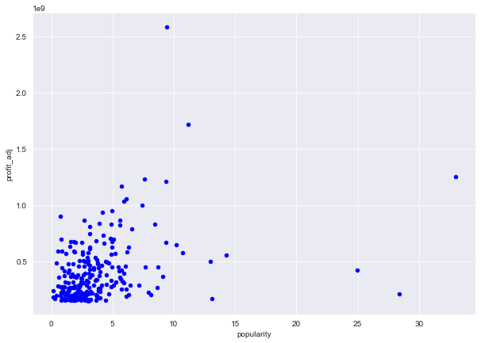

```python
# Create a scatter plot for popularity and profit_adj
df_last_ten_years.plot(x='popularity', y='profit_adj', color='blue', kind='scatter', figsize=(10,7));
```

> > **Q 2a. Quick observation:**
> > - We can observe that popularity and profit_adj seem to have a slight positive correlation although there are outliers.
> > - To confirm the correlation, we need further statistical tests which is not in the scope of our analysis.
> > - **Note:** It is important here to note here that we do not imply that higher popularity alone will lead to an increase in profits. There can be other factors (third variable) which can influence and even modify the existing correlation between popularity and profit.

> **Q 2b. What is the correlation between budget and profitability?**

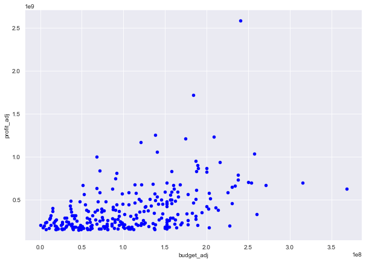

```python
# Create a scatter plot for budget_adj and profit_adj
df_last_ten_years.plot(x='budget_adj', y='profit_adj', kind='scatter',color ='blue',figsize=(10,7));
```

> > **Q 2b. Quick observation:**
> > - We can observe from the scatter plot above that there seems to be a very weak positive correlation between budget_adj and profit_adj.
> > - **Note:** We do not imply that an increase in budget alone will lead to an increase in profits. Further statistical tests are needed to confirm the same, which is out of the scope of our analysis.

> **Q 2c. What is the correlation between budget, revenue and profit over the years?**

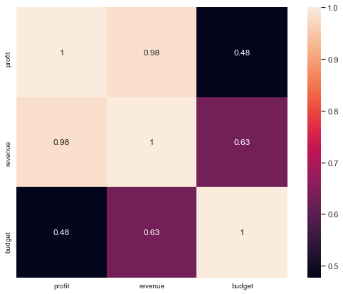

```python
# Create a heatmap using Seaborn
df_correlate = pd.DataFrame(df_last_ten_years, columns =['profit_adj','revenue_adj', 'budget_adj'])

fig, ax = plt.subplots(figsize=(10,7))
sns.set(font_scale=1)
correlate = df_correlate.corr()

# Provide clear labels/axis names
x_axis_label = ['profit', 'revenue', 'budget']
y_axis_label = ['profit', 'revenue', 'budget']
sns.heatmap(correlate,annot=True, xticklabels=x_axis_label, yticklabels=y_axis_label, ax=ax, square=True)
plt.show();
```

> > **Q 2c. Quick observation:**
> > - From the above correlation heatmap, it is observed that revenue has a high positive correlation with profit. However, further statistical tests are needed to confirm that if the revenue increases, the profit also increases solely due to the impact of revenue. And, budget has a mild positive correlation with profit. Also, revenue has a mild positive correlation with budget.
> > - **Note:** It is to be noted here that correlation between two variables does not imply causal relationship. There could be a third (or more) causal variable (s) that affects the correlation.

Further, we intend to find out the most used genres in movies released over the years. This gives us an idea which genres are more popular. Also, we analyse to see if the popular genres have a correlation to profitability.

> **Q 2d. Which are the top 5 genres in movies?**

First, we need to split the 'genres' column. 'Genres' column has to be split since it holds multiple values that are separated by '|'

```python
# Split Genres since 'genre' column holds multiple genre values separated by |
df_genres = df_last_ten_years.assign(genres = df_last_ten_years['genres'].str.split('|')).explode('genres')

# Confirm and check how the split column looks like
df_genres.head()
```

|  | popularity | budget | revenue | original_title | cast | director | keywords | runtime | genres | production_companies | release_date | vote_count | vote_average | release_year | budget_adj | revenue_adj | profit | profit_adj |
| --- | --- | --- | --- | --- | --- | --- | --- | --- | --- | --- | --- | --- | --- | --- | --- | --- | --- | --- |
| 0 | 32.99 | 150000000 | 1513528810 | Jurassic World | Chris Pratt\|Bryce Dallas Howard\|Irrfan Khan\|Vi... | Colin Trevorrow | monster\|dna\|tyrannosaurus rex\|velociraptor\|island | 124.00 | Action | Universal Studios\|Amblin Entertainment\|Legenda... | 2015-06-09 | 5562 | 6.50 | 2015 | 137999939 | 1392445892 | 1363528810 | 1254445953 |
| 0 | 32.99 | 150000000 | 1513528810 | Jurassic World | Chris Pratt\|Bryce Dallas Howard\|Irrfan Khan\|Vi... | Colin Trevorrow | monster\|dna\|tyrannosaurus rex\|velociraptor\|island | 124.00 | Adventure | Universal Studios\|Amblin Entertainment\|Legenda... | 2015-06-09 | 5562 | 6.50 | 2015 | 137999939 | 1392445892 | 1363528810 | 1254445953 |
| 0 | 32.99 | 150000000 | 1513528810 | Jurassic World | Chris Pratt\|Bryce Dallas Howard\|Irrfan Khan\|Vi... | Colin Trevorrow | monster\|dna\|tyrannosaurus rex\|velociraptor\|island | 124.00 | Science Fiction | Universal Studios\|Amblin Entertainment\|Legenda... | 2015-06-09 | 5562 | 6.50 | 2015 | 137999939 | 1392445892 | 1363528810 | 1254445953 |
| 0 | 32.99 | 150000000 | 1513528810 | Jurassic World | Chris Pratt\|Bryce Dallas Howard\|Irrfan Khan\|Vi... | Colin Trevorrow | monster\|dna\|tyrannosaurus rex\|velociraptor\|island | 124.00 | Thriller | Universal Studios\|Amblin Entertainment\|Legenda... | 2015-06-09 | 5562 | 6.50 | 2015 | 137999939 | 1392445892 | 1363528810 | 1254445953 |
| 1 | 28.42 | 150000000 | 378436354 | Mad Max: Fury Road | Tom Hardy\|Charlize Theron\|Hugh Keays-Byrne\|Nic... | George Miller | future\|chase\|post-apocalyptic\|dystopia\|australia | 120.00 | Action | Village Roadshow Pictures\|Kennedy Miller Produ... | 2015-05-13 | 6185 | 7.10 | 2015 | 137999939 | 348161292 | 228436354 | 210161353 |

Next we assign a count to each genre. The count holds the number of films released for each genre.

```python
# Assign the count of movies in each genre to a new data frame. Limit the genres to top 5.
df_genre_count = df_genres.genres.value_counts().head(5)
df_genre_count.head()
```

```
Adventure    125
Action       120
Comedy        84
Family        73
Thriller      70
Name: genres, dtype: int64
```

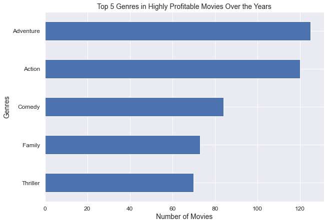

```python
#Plotting a bar chart to show the top 5 genres used in highly profitable movies
df_genre_count.sort_values(ascending=True).plot(kind='barh', figsize=(10,7), fontsize=12);
plt.title('Top 5 Genres in Highly Profitable Movies Over the Years', fontsize=14)
plt.ylabel('Genres', fontsize=14)
plt.xlabel('Number of Movies', fontsize=14)
plt.show()
```

From the above bar chart, we see that movies with 'Adventure' genre is the most produced among the highly profitable movies.

Let us see if mean profits for genres associated with more profitability.

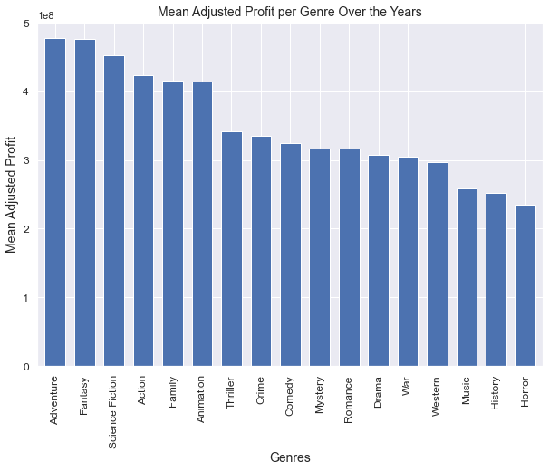

```python
# Create a new data frame that holds the mean value of profit (adj)
df_genres_profit = df_genres.groupby('genres')['profit_adj'].mean()

#Plot a bar chart with mean profits for each genre and arrange genres by descending order of profit
df_genres_profit.sort_values(ascending=False).plot(kind='bar', width = 0.7, figsize=(10,7), fontsize=12);
plt.title('Mean Adjusted Profit per Genre Over the Years', fontsize=14)
plt.ylabel('Mean Adjusted Profit',fontsize=14)
plt.xlabel('Genres',fontsize=14)
plt.show()
```

> > **Q 2d. Quick observation:**
> > - We observe that movies with 'Adventure' genre is the most produced among the highly profitable movies.
> > - We observe that the mean adjusted profit for 'Adventure' and 'Fantasy' genres is one of the highest. 'Action' genre also has a high mean profit.
> > - **Note:** The observations are only tentative. Also the observations based on the subset of data as we defined before. The observations can vary if the parameters of our data set, such as years or profit threshold, is altered.

## Conclusions

The analysis covers the general trend of important variables and then delves deeper into exploring variables such as popularity, budget, genres and revenue, and their impact on the profitability of a movie.

The following websites/ blogs have been reffered in addition to the provided course materials:

- 1. https://pandas.pydata.org/docs/user_guide/index.html
- 1. https://matplotlib.org/stable/users/index.html
- 1. https://seaborn.pydata.org/introduction.html
- 1. https://stackabuse.com/python-how-to-handle-missing-dataframe-values-in-pandas
- 1. https://www.kite.com/python/answers/how-to-format-pandas-scientific-notation-for-floats-in-python
- 1. https://vitalflux.com/correlation-heatmap-with-seaborn-pandas
- 1. https://stats.stackexchange.com/questions/392517/how-can-one-interpret-a-heat-map-plot